# Eflows Species Clustering in CA Regions

## Overview and Basic Methods

In this version (June 2018) of the clustering, translocations were *not* included. Clusters must be contiguous in this version, as determined by a shared boundary or vertex, not by hydrologic connectivity. All HUCs were included, regardless of the minimum number of taxa (includes ones with one or none). Clustering was done with Flow Sensitive Taxa.

Clustering was done by a PISCES tool that subsets and formulates the data to be used by ArcGIS’ Grouping Analysis tool, where prior versions were clustered through manual steps and then fed into GeoDa’s K-Means tool.

## Map of Region Breakouts

The region was broken out primarily into * North Coast (North Coast->San Francisco) * South Coast (South of SF -> Southern California) * Central Valley (anything draining out through the Central Valley - excludes Honey/Eagle Lakes and SF Bay) * Great Basin (anything in hydrologic region 16 in the northern part of the state, contiguous) * Desert - not clustered or shown here as previous clustering indicated single-species driven areas (Includes eastern sierra that is part of region 18, souther reaches of region 15 in the state, portion of Colorado River, and a small piece of region 16)

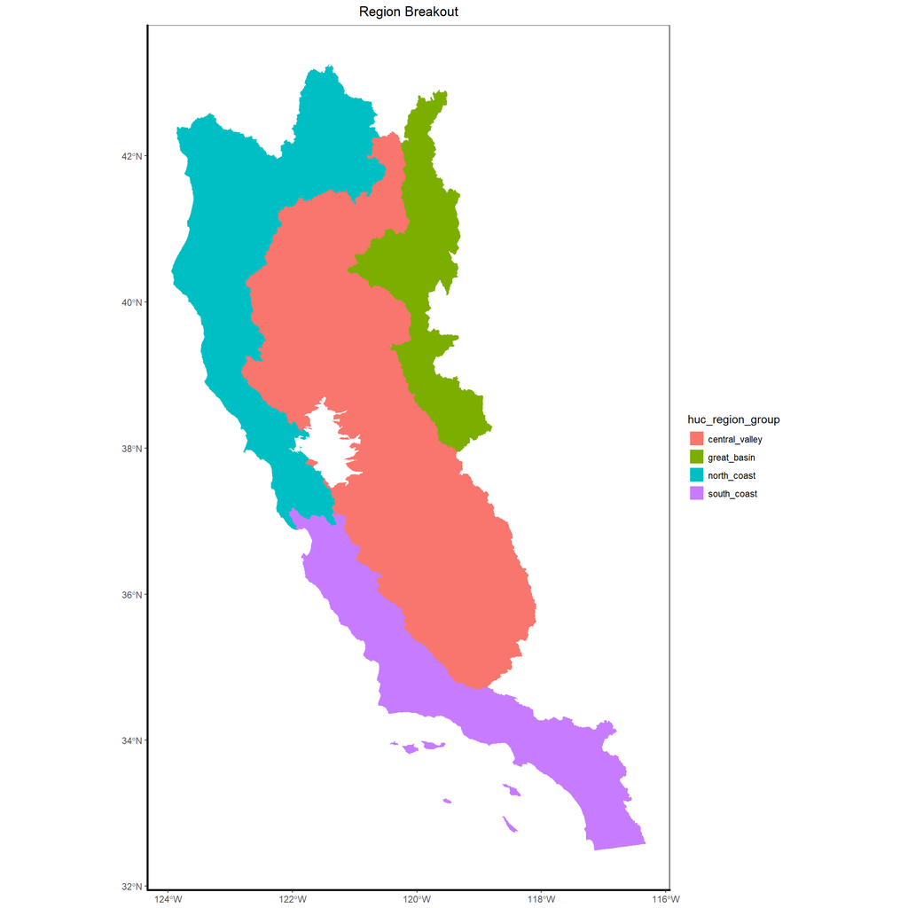

```r
writeLines("td, th { padding : 6px } th { background-color : #fff ; color : #000; border : 1px solid #333; } td { color : #000 ; border : 1px solid #333 }", con = "mystyle.css")  # add the CSS for the data tables

ggplot() +
  geom_sf(huc_data, lwd = 5, mapping=aes(fill=huc_region_group), color=NA)+
  ggtitle("Region Breakout") +
  theme_bw()+
  theme(panel.grid.major = element_line(colour = 'transparent'))+
  theme(strip.background = element_blank(), # facet theme control
        strip.placement = "outside",
        axis.line.x = element_line(color="black", size = 1),
        axis.line.y = element_line(color="black", size = 1),
        plot.title = element_text(hjust = 0.5))
```

## Central Valley

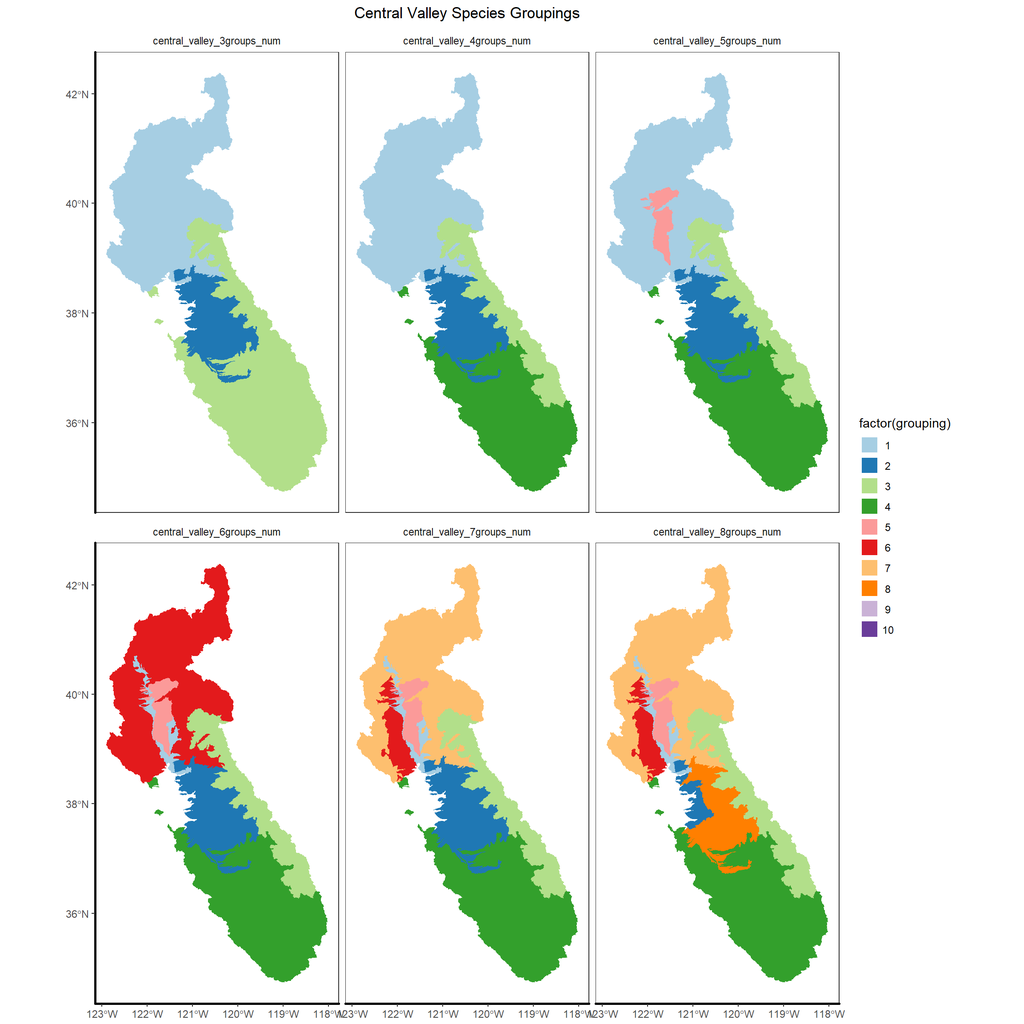

```r
cv_region_name = "central_valley"
cv_species_info <- species_maps(cv_region_name, "Central Valley", huc_data)
cv_species_info$region_map  # print the map
```

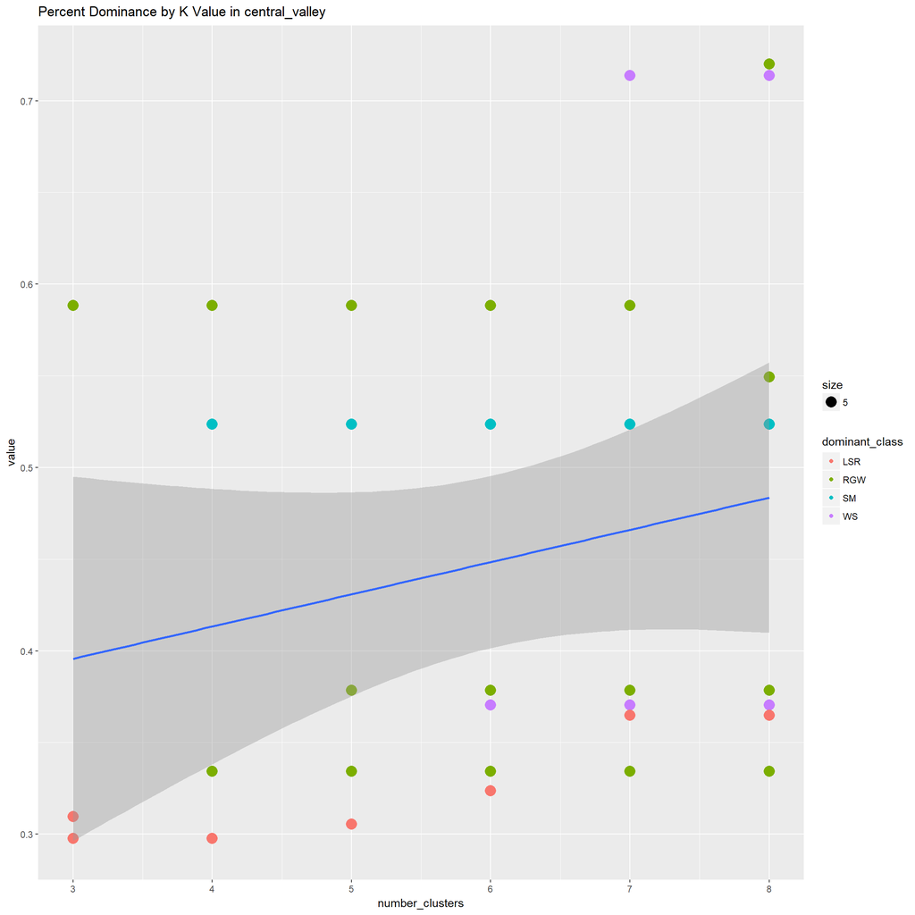

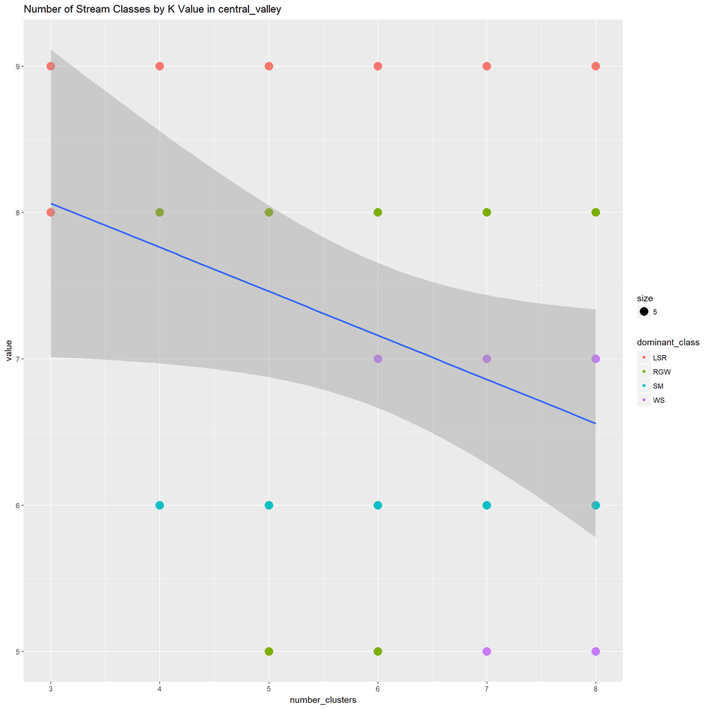

```r
print_dominance_plots(cv_species_info, cv_region_name)
```

```r
cv_species_lists <- species_lists_by_group_dfs(cv_species_info$species_data, cv_region_name)  # species_info$species_data is the data frame for the region
for(df in cv_species_lists){
  show(knitr::kable(df, format="html"))
}
```

| group_1 | group_2 | group_3 |
| --- | --- | --- |
| acipenseridae | acipenseridae | catostomidae |
| catostomidae | catostomidae | cottidae |
| cottidae | cottidae | cyprinidae |
| cyprinidae | cyprinidae | gasterosteidae |
| embiotocidae | embiotocidae | petromyzontidae |
| gasterosteidae | gasterosteidae | salmonidae |
| petromyzontidae | petromyzontidae | NA |
| salmonidae | salmonidae | NA |

| group_1 | group_2 | group_3 | group_4 |
| --- | --- | --- | --- |
| acipenseridae | acipenseridae | catostomidae | catostomidae |
| catostomidae | catostomidae | cottidae | cottidae |
| cottidae | cottidae | cyprinidae | cyprinidae |
| cyprinidae | cyprinidae | salmonidae | gasterosteidae |
| embiotocidae | embiotocidae | NA | petromyzontidae |
| gasterosteidae | gasterosteidae | NA | salmonidae |
| petromyzontidae | petromyzontidae | NA | NA |
| salmonidae | salmonidae | NA | NA |

| group_1 | group_2 | group_3 | group_4 | group_5 |
| --- | --- | --- | --- | --- |
| acipenseridae | acipenseridae | catostomidae | catostomidae | catostomidae |
| catostomidae | catostomidae | cottidae | cottidae | cottidae |
| cottidae | cottidae | cyprinidae | cyprinidae | cyprinidae |
| cyprinidae | cyprinidae | salmonidae | gasterosteidae | embiotocidae |
| embiotocidae | embiotocidae | NA | petromyzontidae | gasterosteidae |
| gasterosteidae | gasterosteidae | NA | salmonidae | petromyzontidae |
| petromyzontidae | petromyzontidae | NA | NA | salmonidae |
| salmonidae | salmonidae | NA | NA | NA |

| group_1 | group_2 | group_3 | group_4 | group_5 | group_6 |
| --- | --- | --- | --- | --- | --- |
| acipenseridae | acipenseridae | catostomidae | catostomidae | catostomidae | catostomidae |
| catostomidae | catostomidae | cottidae | cottidae | cottidae | cottidae |
| cottidae | cottidae | cyprinidae | cyprinidae | cyprinidae | cyprinidae |
| cyprinidae | cyprinidae | salmonidae | gasterosteidae | embiotocidae | embiotocidae |
| embiotocidae | embiotocidae | NA | petromyzontidae | gasterosteidae | gasterosteidae |
| gasterosteidae | gasterosteidae | NA | salmonidae | petromyzontidae | petromyzontidae |
| petromyzontidae | petromyzontidae | NA | NA | salmonidae | salmonidae |
| salmonidae | salmonidae | NA | NA | NA | NA |

| group_1 | group_2 | group_3 | group_4 | group_5 | group_6 | group_7 |
| --- | --- | --- | --- | --- | --- | --- |
| acipenseridae | acipenseridae | catostomidae | catostomidae | catostomidae | catostomidae | catostomidae |
| catostomidae | catostomidae | cottidae | cottidae | cottidae | cottidae | cottidae |
| cottidae | cottidae | cyprinidae | cyprinidae | cyprinidae | cyprinidae | cyprinidae |
| cyprinidae | cyprinidae | salmonidae | gasterosteidae | embiotocidae | embiotocidae | embiotocidae |
| embiotocidae | embiotocidae | NA | petromyzontidae | gasterosteidae | gasterosteidae | gasterosteidae |
| gasterosteidae | gasterosteidae | NA | salmonidae | petromyzontidae | petromyzontidae | petromyzontidae |
| petromyzontidae | petromyzontidae | NA | NA | salmonidae | salmonidae | salmonidae |
| salmonidae | salmonidae | NA | NA | NA | NA | NA |

| group_1 | group_2 | group_3 | group_4 | group_5 | group_6 | group_7 | group_8 |
| --- | --- | --- | --- | --- | --- | --- | --- |
| acipenseridae | catostomidae | catostomidae | catostomidae | catostomidae | catostomidae | catostomidae | acipenseridae |
| catostomidae | cottidae | cottidae | cottidae | cottidae | cottidae | cottidae | catostomidae |
| cottidae | cyprinidae | cyprinidae | cyprinidae | cyprinidae | cyprinidae | cyprinidae | cottidae |
| cyprinidae | embiotocidae | salmonidae | gasterosteidae | embiotocidae | embiotocidae | embiotocidae | cyprinidae |
| embiotocidae | gasterosteidae | NA | petromyzontidae | gasterosteidae | gasterosteidae | gasterosteidae | embiotocidae |
| gasterosteidae | petromyzontidae | NA | salmonidae | petromyzontidae | petromyzontidae | petromyzontidae | gasterosteidae |
| petromyzontidae | salmonidae | NA | NA | salmonidae | salmonidae | salmonidae | petromyzontidae |
| salmonidae | NA | NA | NA | NA | NA | NA | salmonidae |

## Great Basin

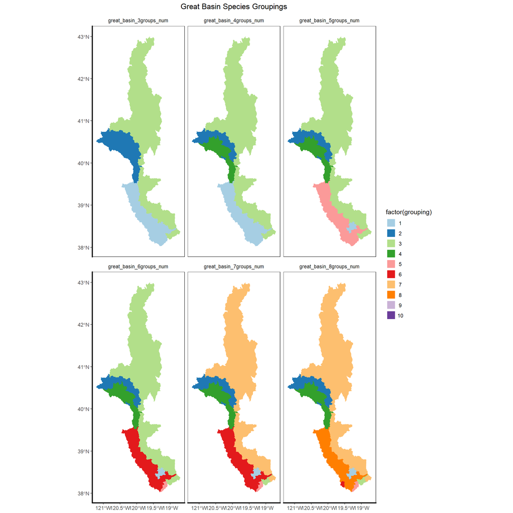

```r
gb_region_name <- "great_basin"
gb_species_info <- species_maps(gb_region_name, "Great Basin", huc_data)
gb_species_info$region_map  # print the map
```

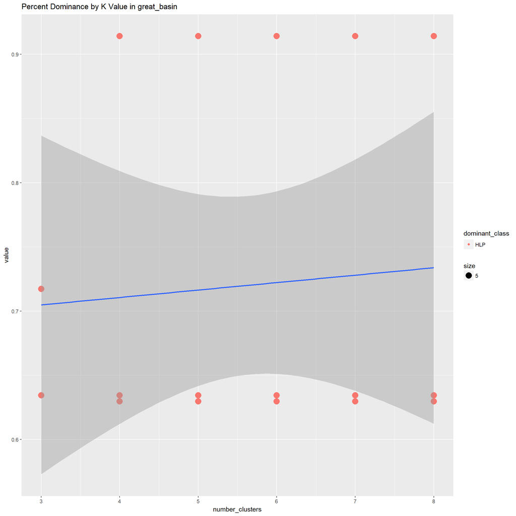

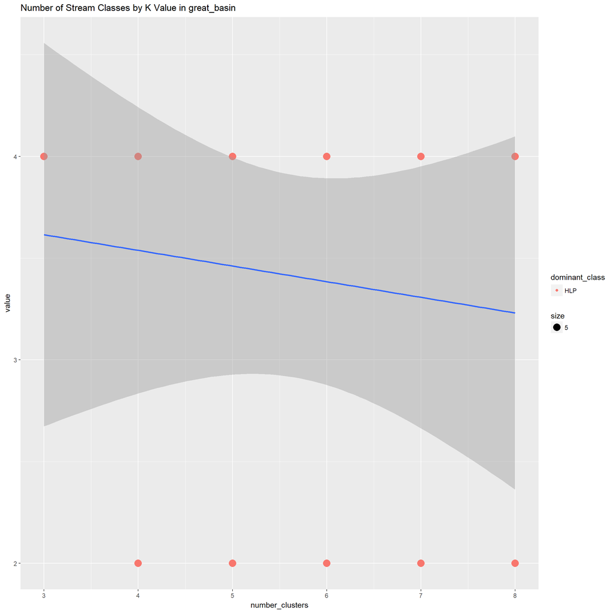

```r
print_dominance_plots(gb_species_info, gb_region_name)
```

```r
gb_species_lists <- species_lists_by_group_dfs(gb_species_info$species_data, gb_region_name)  # species_info$species_data is the data frame for the region
for(df in gb_species_lists){
  show(knitr::kable(df, format="html"))
}
```

| group_1 | group_2 | group_3 |
| --- | --- | --- |
| catostomidae | catostomidae | cyprinidae |
| cyprinidae | cyprinidae | NA |
| salmonidae | NA | NA |

| group_1 | group_2 | group_3 | group_4 |
| --- | --- | --- | --- |
| catostomidae | cyprinidae | cyprinidae | catostomidae |
| cyprinidae | NA | NA | cyprinidae |
| salmonidae | NA | NA | NA |

| group_1 | group_2 | group_3 | group_4 | group_5 |
| --- | --- | --- | --- | --- |
| catostomidae | cyprinidae | cyprinidae | catostomidae | catostomidae |
| cyprinidae | NA | NA | cyprinidae | cyprinidae |
| NA | NA | NA | NA | salmonidae |

| group_1 | group_2 | group_3 | group_4 | group_5 | group_6 |
| --- | --- | --- | --- | --- | --- |
| catostomidae | cyprinidae | cyprinidae | catostomidae | catostomidae | catostomidae |
| cyprinidae | NA | NA | cyprinidae | cyprinidae | cyprinidae |
| NA | NA | NA | NA | NA | salmonidae |

| group_1 | group_2 | group_3 | group_4 | group_5 | group_6 | group_7 |
| --- | --- | --- | --- | --- | --- | --- |
| catostomidae | cyprinidae | cyprinidae | catostomidae | catostomidae | catostomidae | cyprinidae |
| cyprinidae | NA | NA | cyprinidae | cyprinidae | cyprinidae | NA |
| NA | NA | NA | NA | NA | salmonidae | NA |

| group_1 | group_2 | group_3 | group_4 | group_5 | group_6 | group_7 | group_8 |
| --- | --- | --- | --- | --- | --- | --- | --- |
| catostomidae | cyprinidae | cyprinidae | catostomidae | catostomidae | catostomidae | cyprinidae | catostomidae |
| cyprinidae | NA | NA | cyprinidae | cyprinidae | cyprinidae | NA | cyprinidae |
| NA | NA | NA | NA | NA | NA | NA | salmonidae |

## North Coast

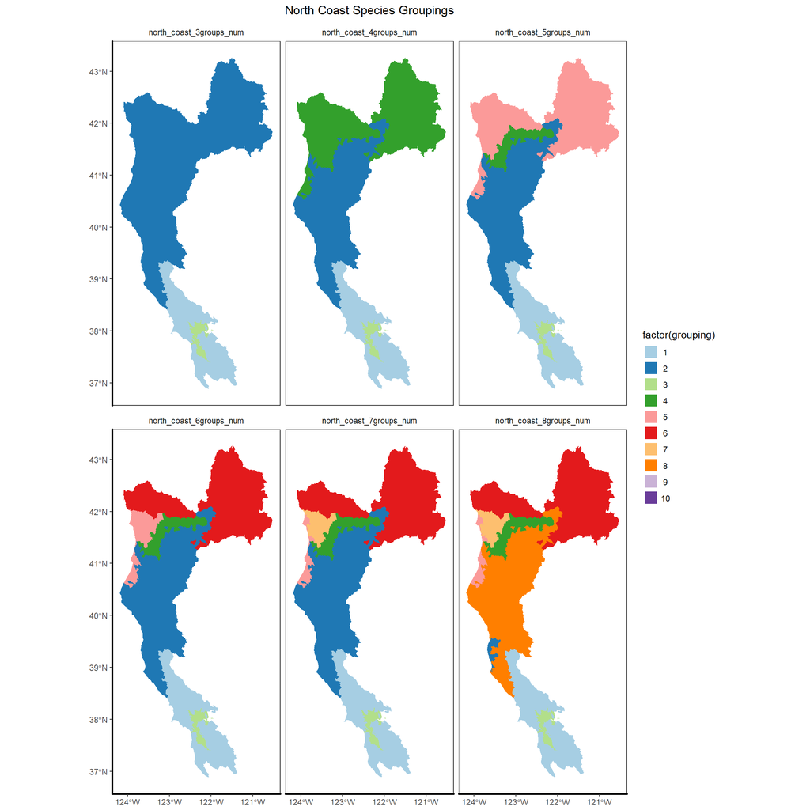

```r
coast_region_name = "north_coast"
coast_species_info <- species_maps(coast_region_name, "North Coast", huc_data)
coast_species_info$region_map  # print the map
```

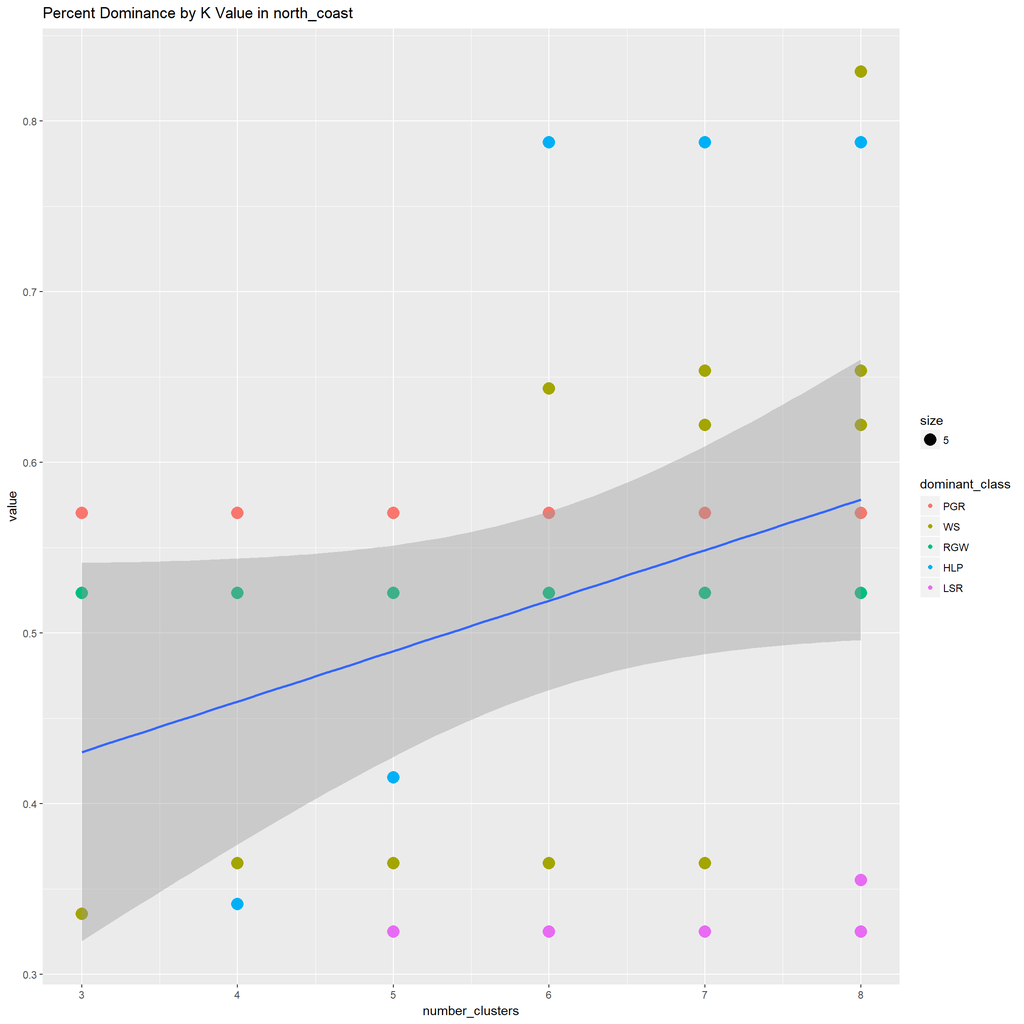

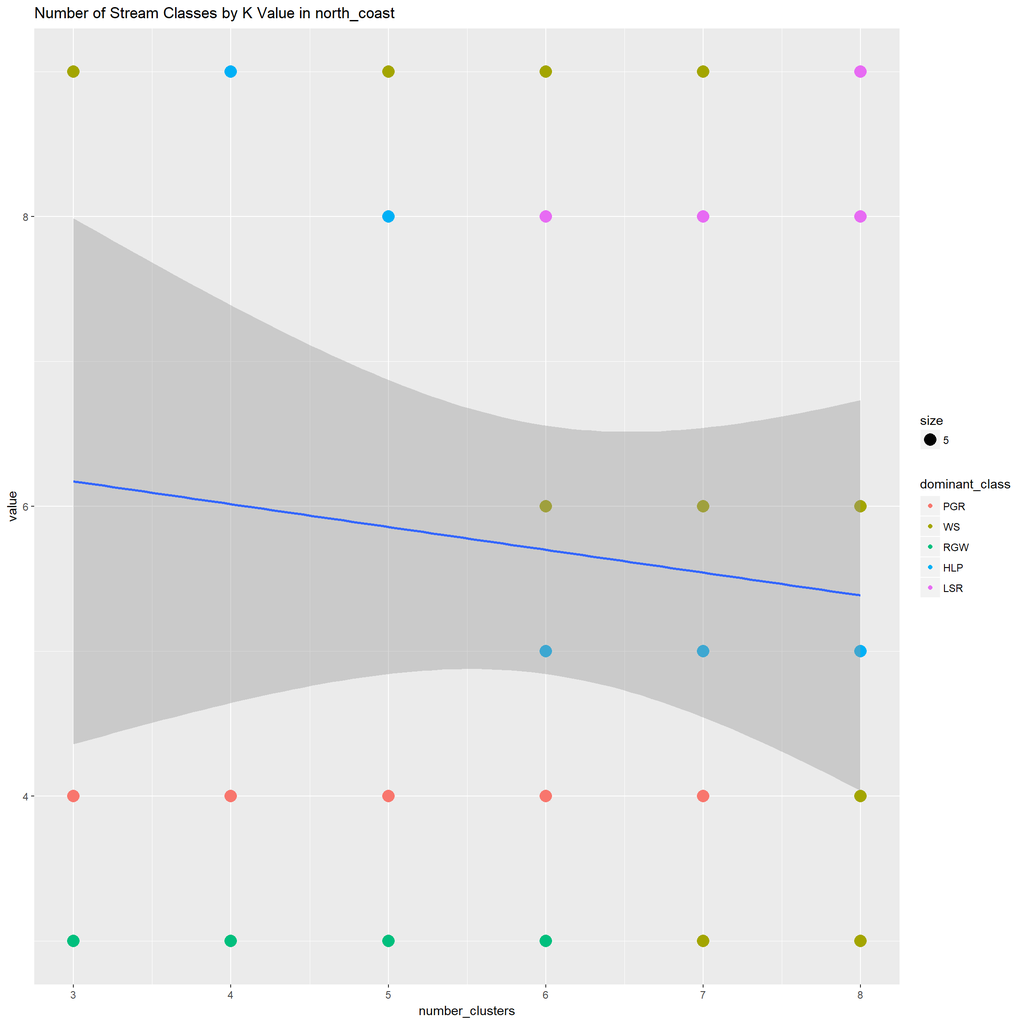

```r
print_dominance_plots(coast_species_info, coast_region_name)
```

```r
coast_species_lists <- species_lists_by_group_dfs(coast_species_info$species_data, coast_region_name)  # species_info$species_data is the data frame for the region
for(df in coast_species_lists){
  show(knitr::kable(df, format="html"))
}
```

| group_1 | group_2 | group_3 |
| --- | --- | --- |
| acipenseridae | acipenseridae | acipenseridae |
| catostomidae | catostomidae | catostomidae |
| cottidae | cottidae | cyprinidae |
| cyprinidae | cyprinidae | embiotocidae |
| embiotocidae | gasterosteidae | gasterosteidae |
| gasterosteidae | gobiidae | osmeridae |
| gobiidae | osmeridae | petromyzontidae |
| osmeridae | petromyzontidae | salmonidae |
| petromyzontidae | salmonidae | NA |
| salmonidae | NA | NA |

| group_1 | group_2 | group_3 | group_4 |
| --- | --- | --- | --- |
| acipenseridae | acipenseridae | acipenseridae | acipenseridae |
| catostomidae | catostomidae | catostomidae | catostomidae |
| cottidae | gasterosteidae | cyprinidae | cottidae |
| cyprinidae | gobiidae | embiotocidae | cyprinidae |
| embiotocidae | petromyzontidae | gasterosteidae | gasterosteidae |
| gasterosteidae | salmonidae | osmeridae | gobiidae |
| gobiidae | NA | petromyzontidae | osmeridae |
| osmeridae | NA | salmonidae | petromyzontidae |
| petromyzontidae | NA | NA | salmonidae |
| salmonidae | NA | NA | NA |

| group_1 | group_2 | group_3 | group_4 | group_5 |
| --- | --- | --- | --- | --- |
| acipenseridae | acipenseridae | acipenseridae | acipenseridae | acipenseridae |
| catostomidae | catostomidae | catostomidae | cottidae | catostomidae |
| cottidae | gasterosteidae | cyprinidae | gasterosteidae | cottidae |
| cyprinidae | gobiidae | embiotocidae | petromyzontidae | cyprinidae |
| embiotocidae | petromyzontidae | gasterosteidae | salmonidae | gasterosteidae |
| gasterosteidae | salmonidae | osmeridae | NA | gobiidae |
| gobiidae | NA | petromyzontidae | NA | osmeridae |
| osmeridae | NA | salmonidae | NA | petromyzontidae |
| petromyzontidae | NA | NA | NA | salmonidae |
| salmonidae | NA | NA | NA | NA |

| group_1 | group_2 | group_3 | group_4 | group_5 | group_6 |
| --- | --- | --- | --- | --- | --- |
| acipenseridae | acipenseridae | acipenseridae | acipenseridae | acipenseridae | catostomidae |
| catostomidae | catostomidae | catostomidae | cottidae | cottidae | cottidae |
| cottidae | gasterosteidae | cyprinidae | gasterosteidae | gasterosteidae | cyprinidae |
| cyprinidae | gobiidae | embiotocidae | petromyzontidae | gobiidae | petromyzontidae |
| embiotocidae | petromyzontidae | gasterosteidae | salmonidae | osmeridae | salmonidae |
| gasterosteidae | salmonidae | osmeridae | NA | petromyzontidae | NA |
| gobiidae | NA | petromyzontidae | NA | salmonidae | NA |
| osmeridae | NA | salmonidae | NA | NA | NA |
| petromyzontidae | NA | NA | NA | NA | NA |
| salmonidae | NA | NA | NA | NA | NA |

| group_1 | group_2 | group_3 | group_4 | group_5 | group_6 | group_7 |
| --- | --- | --- | --- | --- | --- | --- |
| acipenseridae | acipenseridae | acipenseridae | acipenseridae | acipenseridae | catostomidae | acipenseridae |
| catostomidae | catostomidae | catostomidae | cottidae | cottidae | cottidae | gasterosteidae |
| cottidae | gasterosteidae | cyprinidae | gasterosteidae | gasterosteidae | cyprinidae | petromyzontidae |
| cyprinidae | gobiidae | embiotocidae | petromyzontidae | gobiidae | petromyzontidae | salmonidae |
| embiotocidae | petromyzontidae | gasterosteidae | salmonidae | osmeridae | salmonidae | NA |
| gasterosteidae | salmonidae | osmeridae | NA | petromyzontidae | NA | NA |
| gobiidae | NA | petromyzontidae | NA | salmonidae | NA | NA |
| osmeridae | NA | salmonidae | NA | NA | NA | NA |
| petromyzontidae | NA | NA | NA | NA | NA | NA |
| salmonidae | NA | NA | NA | NA | NA | NA |

| group_1 | group_2 | group_3 | group_4 | group_5 | group_6 | group_7 | group_8 |
| --- | --- | --- | --- | --- | --- | --- | --- |
| acipenseridae | catostomidae | acipenseridae | acipenseridae | acipenseridae | catostomidae | acipenseridae | acipenseridae |
| catostomidae | gasterosteidae | catostomidae | cottidae | cottidae | cottidae | gasterosteidae | catostomidae |
| cottidae | gobiidae | cyprinidae | gasterosteidae | gasterosteidae | cyprinidae | petromyzontidae | gasterosteidae |
| cyprinidae | petromyzontidae | embiotocidae | petromyzontidae | gobiidae | petromyzontidae | salmonidae | petromyzontidae |
| embiotocidae | salmonidae | gasterosteidae | salmonidae | osmeridae | salmonidae | NA | salmonidae |
| gasterosteidae | NA | osmeridae | NA | petromyzontidae | NA | NA | NA |
| gobiidae | NA | petromyzontidae | NA | salmonidae | NA | NA | NA |
| osmeridae | NA | salmonidae | NA | NA | NA | NA | NA |
| petromyzontidae | NA | NA | NA | NA | NA | NA | NA |
| salmonidae | NA | NA | NA | NA | NA | NA | NA |

## South Coast

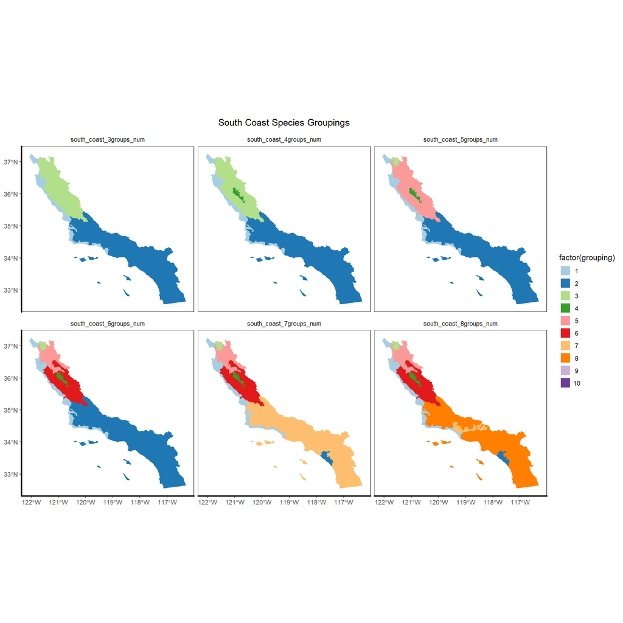

```r
soco_region_name = "south_coast"
soco_species_info <- species_maps(soco_region_name, "South Coast", huc_data)
soco_species_info$region_map  # print the map
```

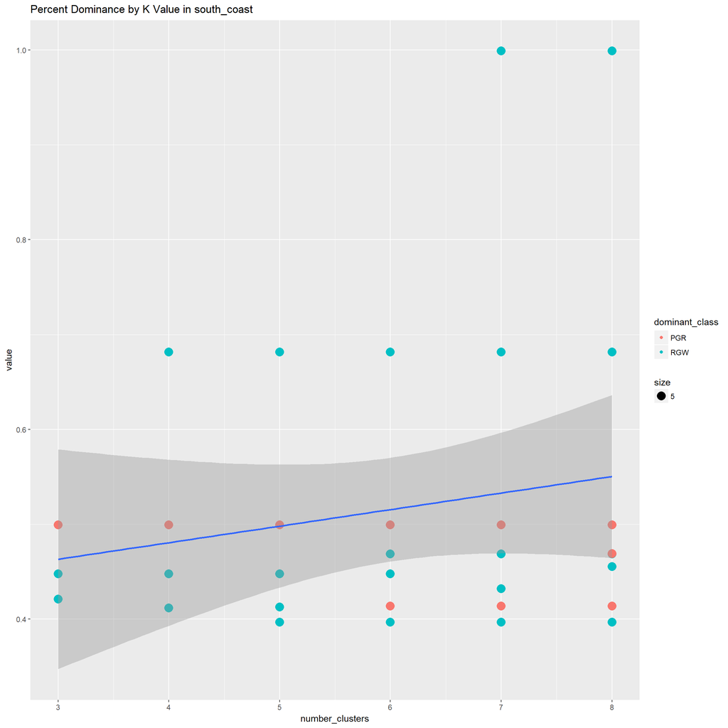

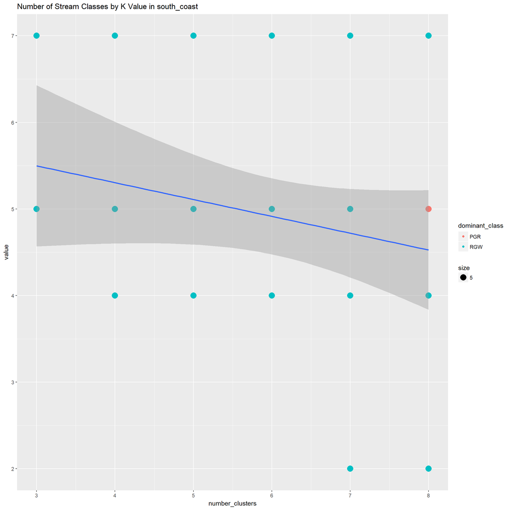

```r
print_dominance_plots(soco_species_info, soco_region_name)
```

```r
soco_species_lists <- species_lists_by_group_dfs(soco_species_info$species_data, soco_region_name)  # species_info$species_data is the data frame for the region
for(df in soco_species_lists){
  show(knitr::kable(df, format="html"))
}
```

| group_1 | group_2 | group_3 |
| --- | --- | --- |
| cyprinidae | catostomidae | catostomidae |
| gasterosteidae | cyprinidae | cottidae |
| gobiidae | gasterosteidae | cyprinidae |
| petromyzontidae | gobiidae | gasterosteidae |
| salmonidae | petromyzontidae | gobiidae |
| NA | salmonidae | petromyzontidae |
| NA | NA | salmonidae |

| group_1 | group_2 | group_3 | group_4 |
| --- | --- | --- | --- |
| cyprinidae | catostomidae | catostomidae | catostomidae |
| gasterosteidae | cyprinidae | cottidae | cottidae |
| gobiidae | gasterosteidae | cyprinidae | cyprinidae |
| petromyzontidae | gobiidae | gasterosteidae | gasterosteidae |
| salmonidae | petromyzontidae | gobiidae | petromyzontidae |
| NA | salmonidae | petromyzontidae | salmonidae |
| NA | NA | salmonidae | NA |

| group_1 | group_2 | group_3 | group_4 | group_5 |
| --- | --- | --- | --- | --- |
| cyprinidae | catostomidae | catostomidae | catostomidae | catostomidae |
| gasterosteidae | cyprinidae | cottidae | cottidae | cyprinidae |
| gobiidae | gasterosteidae | cyprinidae | cyprinidae | gasterosteidae |
| petromyzontidae | gobiidae | gasterosteidae | gasterosteidae | gobiidae |
| salmonidae | petromyzontidae | gobiidae | petromyzontidae | petromyzontidae |
| NA | salmonidae | petromyzontidae | salmonidae | salmonidae |
| NA | NA | salmonidae | NA | NA |

| group_1 | group_2 | group_3 | group_4 | group_5 | group_6 |
| --- | --- | --- | --- | --- | --- |
| cyprinidae | catostomidae | catostomidae | catostomidae | catostomidae | catostomidae |
| gasterosteidae | cyprinidae | cottidae | cottidae | cyprinidae | cyprinidae |
| gobiidae | gasterosteidae | cyprinidae | cyprinidae | gasterosteidae | petromyzontidae |
| petromyzontidae | gobiidae | gasterosteidae | gasterosteidae | gobiidae | salmonidae |
| salmonidae | petromyzontidae | gobiidae | petromyzontidae | petromyzontidae | NA |
| NA | salmonidae | petromyzontidae | salmonidae | salmonidae | NA |
| NA | NA | salmonidae | NA | NA | NA |

| group_1 | group_2 | group_3 | group_4 | group_5 | group_6 | group_7 |
| --- | --- | --- | --- | --- | --- | --- |
| cyprinidae | cyprinidae | catostomidae | catostomidae | catostomidae | catostomidae | catostomidae |
| gasterosteidae | gobiidae | cottidae | cottidae | cyprinidae | cyprinidae | cyprinidae |
| gobiidae | petromyzontidae | cyprinidae | cyprinidae | gasterosteidae | petromyzontidae | gasterosteidae |
| petromyzontidae | salmonidae | gasterosteidae | gasterosteidae | gobiidae | salmonidae | gobiidae |
| salmonidae | NA | gobiidae | petromyzontidae | petromyzontidae | NA | petromyzontidae |
| NA | NA | petromyzontidae | salmonidae | salmonidae | NA | salmonidae |
| NA | NA | salmonidae | NA | NA | NA | NA |

| group_1 | group_2 | group_3 | group_4 | group_5 | group_6 | group_7 | group_8 |
| --- | --- | --- | --- | --- | --- | --- | --- |
| cyprinidae | cyprinidae | catostomidae | catostomidae | catostomidae | catostomidae | gasterosteidae | catostomidae |
| gasterosteidae | gobiidae | cottidae | cottidae | cyprinidae | cyprinidae | gobiidae | cyprinidae |
| gobiidae | petromyzontidae | cyprinidae | cyprinidae | gasterosteidae | petromyzontidae | petromyzontidae | gasterosteidae |
| petromyzontidae | salmonidae | gasterosteidae | gasterosteidae | gobiidae | salmonidae | salmonidae | gobiidae |
| salmonidae | NA | gobiidae | petromyzontidae | petromyzontidae | NA | NA | petromyzontidae |
| NA | NA | petromyzontidae | salmonidae | salmonidae | NA | NA | salmonidae |
| NA | NA | salmonidae | NA | NA | NA | NA | NA |